# 5072-HW1-Hanzhang_Hu

```r
library("rjson")
library("tidyverse")
library("stringr")
library("plyr")
```

```r
library("ggwordcloud")
```

# About this GitHub Project

Although there are printed collections, most people do not have the physical books. The electronic version is convenient for copying, so this open source database was born. This database is distributed in JSON format, making it easy for people to start their own projects.

### This Chinese poetry database includes:

- The composition of Chinese Poetry Database:
  - Poetry from Tang Dynasty
    - 55,000 poems
  - Poetry from Song Dynasty
    - 280,000 poems
  - Poetry from other dynasties
    - no numeric information

### Why I choose this GitHub Project

Recently, I’m reading the one of Four Great Classical Novel, Three Kingdoms. I really like that novel, and I really like Cao Cao, who is the most wisdom man in the novel. So I chose the Cao Cao’s poetry in my report, I analyzed Cao Cao peotry’s main title to know more about his poems.

# About Three Kingdoms

### The History

The Three Kingdoms (simplified Chinese: 三国时代) from 220 to 280 AD was the tripartite division of China among the states of Wei, Shu, and Wu. The Three Kingdoms period started with the end of the Han dynasty and was followed by the Jin dynasty.

### The Novel

Three Kingdoms (simplified Chinese) is a 14th-century historical novel attributed to Luo Guanzhong. It is set in the turbulent years towards the end of the Han dynasty and the Three Kingdoms period in Chinese history, starting in 169 AD and ending with the reunification of the land in 280 by Western Jin. The novel is based primarily on the Records of the Three Kingdoms (三国志), written by Chen Shou.

# About Caocao

Cao Cao (Chinese: 曹操),courtesy name Mengde, was a Chinese poet, statesman, and warlord. He was the penultimate grand chancellor of the Eastern Han dynasty who rose to great power in the final years of the dynasty. As one of the central figures of the Three Kingdoms period, he laid the foundations for what was to become the state of Cao Wei and was posthumously honored as “Emperor Wu of Wei” although he never officially claimed the title Emperor of China or proclaimed himself “Son of Heaven” during his lifetime

### Reference

1. [Three Kingdoms](https://en.wikipedia.org/wiki/Three_Kingdoms)
2. [Romance of the Three Kingdoms](https://en.wikipedia.org/wiki/Romance_of_the_Three_Kingdoms)
3. [Cao Cao](https://en.wikipedia.org/wiki/Cao_Cao), https://en.wikipedia.org/wiki/Cao_Cao

```r
json_file <- "https://raw.githubusercontent.com/chinese-poetry/chinese-poetry/master/caocaoshiji/caocao.json"
caocao_data <- fromJSON(paste(readLines(json_file), collapse=""))
# extract title from Caocao's poems and create the title dataframe
title <- sapply(caocao_data, function(x) x [[1]])
title_frame <- tibble(title)

# use word() function from "stringr" package to keep the main poem titles and eliminate the sub titles，
# which eliminate the sub title after a space
main_titles <- word(title_frame[[1]], 1)

# count the frequency of the main title
title_freq <- count(word(title_frame[[1]], 1))

# arrange the frequency in a descending way
title_sort <- arrange(title_freq, desc(freq))
names(title_sort)[names(title_sort) == "x"] <- "Main_Title"
names(title_sort)[names(title_sort) == "freq"] <- "Frequency"
```

```r
library(knitr)
kable(title_sort, align = "lccrr")
```

| Main_Title | Frequency |
| --- | --- |
| 步出夏门行 | 3 |
| 气出唱 | 3 |
| 善哉行 | 3 |
| 短歌行 | 2 |
| 秋胡行 | 2 |
| 董逃歌词 | 1 |
| 度关山 | 1 |
| 对酒 | 1 |
| 观沧海 | 1 |
| 龟虽寿 | 1 |
| 蒿里行 | 1 |
| 精列 | 1 |
| 苦寒行 | 1 |
| 陌上桑 | 1 |
| 却东西门行 | 1 |
| 塘上行 | 1 |
| 薤露行 | 1 |
| 谣俗词 | 1 |

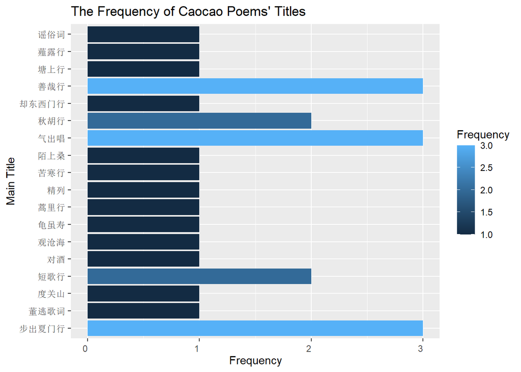

```r
ggplot(title_sort, aes(x=Main_Title, y=Frequency, fill=Frequency)) +
  geom_bar(stat = "identity") +
  theme(axis.text.x = element_text(angle = 0, vjust = 0.5, hjust=1)) +
  coord_flip() +
  labs(title = "The Frequency of Caocao Poems' Titles",
              y = "Frequency", x = "Main Title") +
  scale_color_gradient(low = "blue", high = "orange")
```

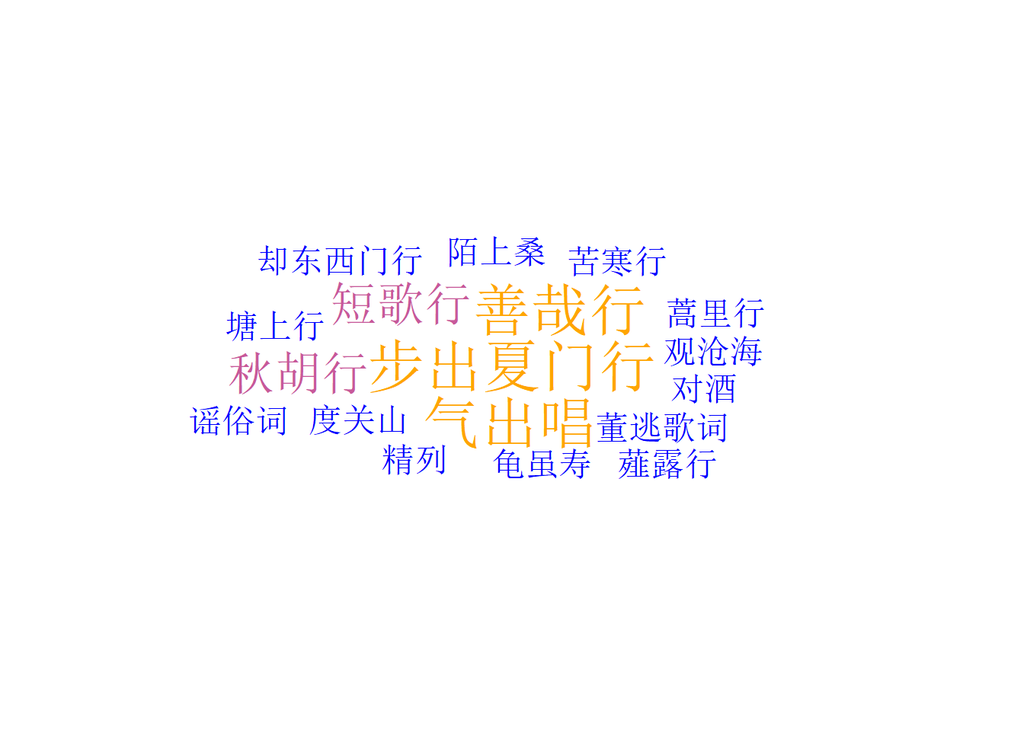

```r
ggplot(title_sort, aes(label = Main_Title, size = Frequency, color = Frequency)) +
  geom_text_wordcloud() +
  scale_size_area(max_size = 10) +
  theme_minimal() +
  scale_color_gradient(low = "blue", high = "orange")
```